# Static Maps - Intro

# 1 Intro: Choropleth Maps

- Choropleth maps display data on a map by shading regions with different colors.
- In this lecture, we focus on packages `ggmap`, `ggplot2`, and `tmap` to create static maps.

## 1.1 Example 1

- Back when there was an effort to impeach Trump, Lara Trump tweeted a map of the US, which looked very red, with the phrase “Try to Impeach This”. A graphical designer, [Karim Douieb](https://www.linkedin.com/in/karim-douieb/), in Brussels (Belgium), who co-founded a company call [Jetpack.ai](https://www.jetpack.ai/), decided to weigh-in on this (American) political issue with an interactive response web page title [“Try to impeach this? Challenge accepted!”](http://try-to-impeach-this.jetpack.ai).

[output not shown]

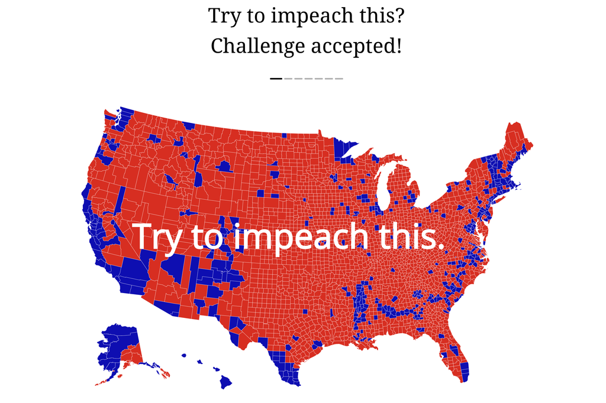

## 1.2 Example 2

- Centers for Disease Control and Prevention provide a weekly influenza surveillance report using a choropleth map.
- Check [Weekly US Map: Influenza Summary Update](https://www.cdc.gov/flu/weekly/usmap.htm)

# 2 Mapping packages

## 2.1 Package: `ggmap`

## 2.2 Obtain Google Maps API Keys

- We need an API key to access Google Maps for these exercises.
  - 1. Visit the Google API console. Click [here](https://console.developers.google.com/apis/dashboard).
  - 2. Go ahead and click the “Create Project button.”
  - 3. Give a name and click “Create”.
  - 4. Click “Enable APIS and Services”.
  - 5. Search for “Maps Static API” and click it. Then, press “Enable”.
  - 6. Search for “Geocoding API” and click it. Then, press “Enable”.
  - 7. Go to “Credentials” and click “Create Credentials”
  - 8. Copy your API key and use it for the exercises below.
- Note that you need to create a billing account before you use your API key in R.
- For more info, see [Get an API Key and Signature](https://developers.google.com/maps/documentation/maps-static/get-api-key) and [Google Maps Platform](https://mapsplatform.google.com/pricing/).

## 2.3 Register Goolge Keys

- Use the `register_google()` function.

```r
library(ggmap)

# google_key = "xxxxxxxxxxxxxxxxxxxxxxxxxxxxxxxxxxxx"

# Insert your API key to get your google map for this session
# -------------------------------------------------------------
# register_google(key = google_key)


# Insert your API key to get your google map permanently
# -------------------------------------------------------------
# register_google(key = google_key, write = TRUE)
# register_google()
# google_key()
```

```r
# register_google()

# Use qmap (quick map) to draw a city map
# qmap("Washington DC", zoom=10)
```